# Matching using R pt.1

Meng Le Zhang

March 3, 2022

# **Who am I?**

- Meng Le Zhang (meng_le.zhang@sheffield.ac.uk)
- my github: https://github.com/MengLeZhang
- my researchgate: https://www.researchgate.net/profile/Meng-Le-Zhang
- check: 00 requirements.R for required packages

# Objectives

- understand what causality is about (potential outcomes framework)
- understand what matching is about
- what to do it using R

## Example: Matching jargon

“In addition, the estimate of interest, the **average treatment effect on the treated (ATT)**…”

“To avoid poor matches (i.e. large differences between regenerated sites and their closest non-regenerated neighbour) a threshold on the maximum propensity score distance, **the radius**, was imposed (**radius matching**)…. The sample is narrowed to the region of **common support**: regeneration sites with a propensity score higher than the maximum or less than the minimum of the control observations were discarded.”

# Course focus

- 1. The effects of causes not causes of effect
  - “Does school quality affect pupil performance”
  - not “Can the inequalities in pupil performance be explained by school quality”
- 2. One type of design – cases where all confounding is observed
- 3. One definition of causality (counterfactuals)

# Set up

1. What is causal inference and lingo (30 min)
2. 15 min task / break
3. Explaining matching using MatchIt (30 min)
4. 15 min task / break
5. Wrap up (30 min)

Confused? Lost track? Check out the cheatsheet

If you have IT issues; the code will be there

# Causality

# Causality and potential outcomes

## Potential outcomes

- **counterfactual**: “relating to or expressing what has not happened or is not the case”

The effects of X on Y:

- Does more education lead to better pay?

Rephrase that as a counterfactual:

- There is a parallel world I didn’t have a degree. Would my wages be any different?

## Potential outcomes

Imagine these worlds:

- world A = I got a degree (real world)
- world B = I didn’t a degree (counterfactual)
- If my wages were differred between A and B then a degree had an effect.
- Causal effect is the difference between my outome and my potential outcome under a counterfactual (hence **potential outcome framework**)

## Potential outcomes

- We cannot observe potential outcomes. But imagine we could:

|  | Sex |  | Outcome world A (if treated) | Outcome world B (if not treated) | Is actually treated? | Outcome (in real life) |
| --- | --- | --- | --- | --- | --- | --- |
| Liam. | M |  | 1 | 0 | T | 1 |
| Noah. | M |  | 1 | 1 | F | 1 |
| Oliver. | M |  | 0 | 0 | T | 0 |
| Amelia. | F |  | 1 | 0 | F | 0 |
| Isabella. | F |  | 0 | 1 | T | 0 |
| Mia. | F |  | 1 | 0 | F | 0 |

# Treatment effects (ATE, ATT, ATU)

|  | Sex |  | Outcome world A (if treated) | Outcome world B (if not treated) | Is actually treated? | Outcome (in real life) |
| --- | --- | --- | --- | --- | --- | --- |
| **Liam.** | M |  | 1 | 0 | T | 1 |
| Noah. | M |  | 1 | 1 | F | 1 |
| **Oliver.** | M |  | 0 | 0 | T | 0 |
| Amelia. | F |  | 1 | 0 | F | 0 |
| **Isabella.** | F |  | 0 | 1 | T | 0 |
| Mia. | F |  | 1 | 0 | F | 0 |

**Average treatment effect (ATE)** Average difference in outcomes between world A and B (treated vs not treated) for the entire sample

$$\frac{(1-0)+ (1-1)+(0-0) + (1-0)+(0-1) + (1-0)}6 = 1/3$$

## Treatment effects (ATE, ATT, ATU)

|  | Sex |  | Outcome world A (if treated) | Outcome world B (if not treated) | Is actually treated? | Outcome (in real life) |
| --- | --- | --- | --- | --- | --- | --- |
| **Liam.** | M |  | 1 | 0 | T | 1 |
| Noah. | M |  | 1 | 1 | F | 1 |
| **Oliver.** | M |  | 0 | 0 | T | 0 |
| Amelia. | F |  | 1 | 0 | F | 0 |
| **Isabella.** | F |  | 0 | 1 | T | 0 |
| Mia. | F |  | 1 | 0 | F | 0 |

**Average treatment effect on the treated(ATT)** Average difference in outcomes between world A and B (treated vs not treated) for only those that **ACTUALLY** received the treatment in real life (Liam, Oliver, Isabella)

$$\frac{(1-0)+ (0-0) + (0-1)}3 = 0$$

## Treatment effects (ATE, ATT, ATU)

|  | Sex |  | Outcome world A (if treated) | Outcome world B (if not treated) | Is actually treated? | Outcome (in real life) |
| --- | --- | --- | --- | --- | --- | --- |
| **Liam.** | M |  | 1 | 0 | T | 1 |
| Noah. | M |  | 1 | 1 | F | 1 |
| **Oliver.** | M |  | 0 | 0 | T | 0 |
| Amelia. | F |  | 1 | 0 | F | 0 |
| **Isabella.** | F |  | 0 | 1 | T | 0 |
| Mia. | F |  | 1 | 0 | F | 0 |

**Average treatment effect on the Untreated (ATU)** Average difference in outcomes between world A and B (treated vs not treated) for only those that **did not** received the treatment in real life (Noah, Amelia, Mia)

$$\frac{(1-1)+(1-0)+ (1-0)}3 = 2/3$$

## Treatment effects (ATE, ATT, ATU)

Why care? They are different quantities

- Imagine a free school meals as a treatment
- Children who are treated may have high benefits (i.e. low income families)
- Children who are not treated may have no benefits (i.e middle income families)
- The ATE is just a weighted version of the ATT and ATU (depending on population of treated and untreated)
- Note: In randomised experiments with equal samples, ATE = ATT = ATU

## Example: Matching jargon

“In addition, the estimate of interest, the **average treatment effect on the treated (ATT)**…”

# Estimating causality

- Estimands, estimators, and estimates
- Randomisation as an estimator

## Estimands, estimators, and estimates

- ATT, ATE and ATU are **estimands**. The goal of our research.
- Our guesses for the ATT, ATE and ATU are **estimates**
- The method we use are **estimators**

## Estimands, estimators, and estimates

[figure not shown]

## Randomisation as an estimator

|  | Sex |  | Outcome world A (if treated) | Outcome world B (if not treated) | Is actually treated? | Outcome (in real life) |
| --- | --- | --- | --- | --- | --- | --- |
| **Liam.** | M |  | 1 | 0 | T | 1 |
| Noah. | M |  | 1 | 1 | F | 1 |
| **Oliver.** | M |  | 0 | 0 | T | 0 |
| Amelia. | F |  | 1 | 0 | F | 0 |
| **Isabella.** | F |  | 0 | 1 | T | 0 |
| Mia. | F |  | 1 | 0 | F | 0 |

- ATE = Mean outcome in world A $(\mu_A)$ - Mean outcome in world B $(\mu_B)$
- Randomise who gets sent to world A and B (i.e. who is actually treated)
- Sample mean of treated is an unbiased **estimator** for $\mu_A$
- Sample mean of untreated is an unbiased **estimator** for $\mu_B$
- The difference between the two is an unbiased **estimate** for the ATE

## Randomisation as an estimator

|  | Sex |  | Outcome world A (if treated) | Outcome world B (if not treated) | Is actually treated? | Outcome (in real life) |
| --- | --- | --- | --- | --- | --- | --- |
| **Liam.** | M |  | 1 | 0 | T | 1 |
| Noah. | M |  | 1 | 1 | F | 1 |
| **Oliver.** | M |  | 0 | 0 | T | 0 |
| Amelia. | F |  | 1 | 0 | F | 0 |
| **Isabella.** | F |  | 0 | 1 | T | 0 |
| Mia. | F |  | 1 | 0 | F | 0 |

- When we deliberately randomise this is an **experiment**.
- When the randomisation occurs without an intent to do an experiment, it is a **natural experiment**.

## Randomisation as an estimator

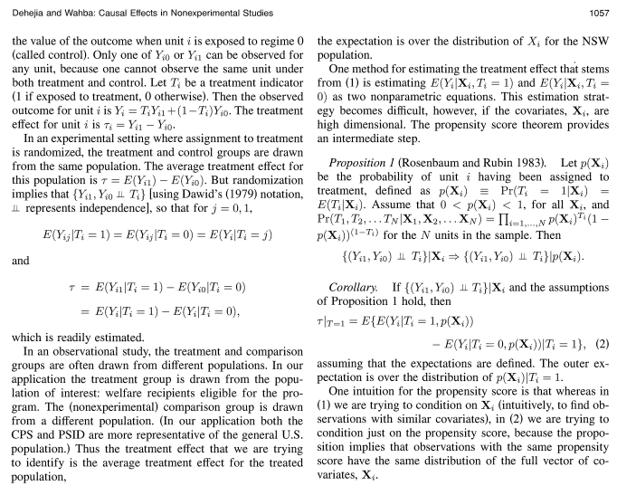

# Non-random selection

- Receiving the treatment is not random. This isn’t a problem unless there are confounders.
- **Confounder**: A common cause of i) treatment status and ii) your outcome.
- Example: Poverty is a common cause of free school meals and absenteeism.

# Matching

- Non-random selection is not an issues if:
- 1. we observe **every confounder**
- 2. we do not try to adjust for **colliders**

## Confounders

If we observe **every confounder** (call it $X$) then we can for the ATT:

- match every treatment case to a control case with identical $X$
- calculate the difference in outcomes between matched pairs

This is an unbiased estimate of the ATT

## Colliders

Never ever match on **colliders**.

**Collider**: In most cases, a collider is a common effect of both your treatment and another variable that affects your outcome. It’s complicated….

This is the reason why people tell you never to condition on post-treatment outcomes….

## Colliders

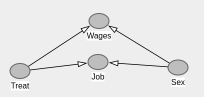

- Estimand: Effect of treatment on Wages
- Job is a collider; never condition on this (e.g. through regression or matching)

# Summary

- Counterfactuals and potential outcomes
- Treatment effects (ATE, ATT, ATU)
- Randomisation
- Confounders and colliders

## Golden rules

- 1. We observe **every** **confounder** (or almost every)
- 2. Don’t condition on **colliders**
- If these conditions are met, causal inference is easy peasy….
- … but getting the conditions just right is 90% of the task

“If your experiment needs statistics, you ought to have done a better experiment.”

# The National Supported Work (NSW) Demonstration data

- US program conducted between 1975 and 1979
- Work experience for individuals who faced economic and social problems
- job training lasting between nine months and a year.
- non-treatment cases come from a population survey (PSID)
- very influential study (explain later)

Task: What was the treatment effect (ATT) of the NSW program?

## The National Supported Work (NSW) Demonstration data

- Person was unemployed before selection
- NSW was aimed at four groups of people with severe employment disadvantages:
  - Female AFDC recipients (Aid to Families with Dependent Children; available to families with low or no income) (25% of participants)
  - ex-drug addicts (21%)
  - ex-offenders (35%)
  - young school dropouts (19%)

## The National Supported Work (NSW) Demonstration data

- We only have males in the sample. The outcome is:
  - wages in 1978 (re78) (in separate file)
- more info here: (https://menglezhang.github.io/matching-causality-course/data-readme.html)

# Task

Open the NSW data and use whatever technique you know to estimate the treatment effect

Pick some estimates you **believe** and let us know what they are

Take 15 minutes

We’ll come back and discuss them

## Task

[figure not shown]